# 01bWhat

Database Management

Mick McQuaid

mcq@utexas.edu

University of Texas at Austin

12 May 2026

# What will you learn?

# what databases are

Databases are structured collections of data. Most databases are relational databases but there are many other types of databases. The website DB-Engines ranks database management systems (dbms) by their perceived popularity (notice that this is not the same thing as actual popularity!). Most of the database management systems there are listed as “multi-model” but they are mainly relational.

# what relational databases are

- Relational databases consist of related tables of information
- Each table looks roughly like a spreadsheet
- Each row describes a unique entity (no duplicate rows are allowed)
- Each column describes a property of the entity (no duplicate column names are allowed)
- The columns are named
- Each column contains only one type of data (text, number, date, etc.)
- The rows can be in any order (they are not ordered)
- The intersection of a row and column is called a cell
- There are technical terms for all these things that we will learn later

# why you should use databases

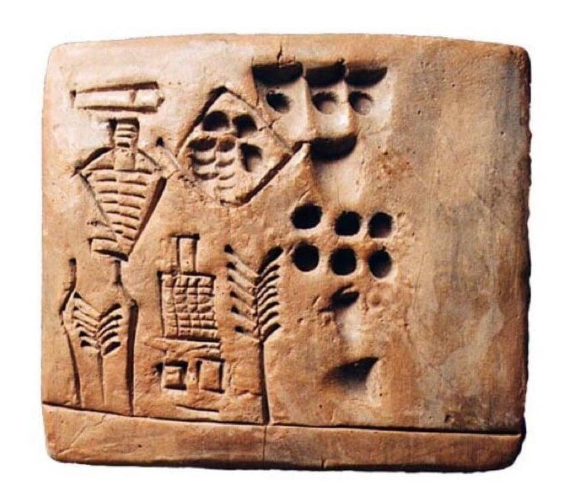

# why you should use databases

- Databases are as old as record-keeping
- Relational databases were invented in the 1970s
- They quickly became the dominant way to store data in organizations
- If implemented correctly, they guard against data anomalies
- They can be made to operate very quickly

# how people work with databases (SQL)

- SQL is pronounced either “sequel” or “ess-que-el”
- It refers to Structured Query Language
- It is the standard language for working with relational databases
- It is one of the oldest computer languages still in use today
- Hence, it is idiosyncratic compared to modern languages like Python
- People have invented all sorts of alternatives to SQL but they only have pockets of adoption
- You are better off learning some SQL than one of the many less-known alternatives
- LLMs (large language models) are good at SQL

# how to get data into and out of databases

- You use a DBMS (database management system) to work with databases
- You can get data into a database using many methods, including a GUI or a command line
- Usually, people write programs to get data into databases, one entity at a time or as a result of an event like a transaction
- You will use CSV (comma separated values) files to get data into and out of databases
- Workgroups often use spreadsheets but the organization as a whole uses databases
- Hence, there needs to be a two-way street

# a particular database management system (SQLite)

- SQLite is a database management system
- It is a “serverless” database management system
- That makes it easy for us to work with
- It is by far the most widely deployed database management system in the world
- It is free and very well documented

# SQLite Deployment

[figure not shown]

# DB-Engines Rankings

[figure not shown]

# more on SQLite

- It is an “embedded” database management system
- That means it is embedded in other programs, such as web browsers, mobile phones, and desktop applications
- It is a “single-user” database management system
- That means it is designed to be used by one person at a time
- It is a “file-based” database management system
- That means it stores all tables of a database in a single file

# normalization of databases

- If you just design a database without regard to anomalies, you will get data anomalies
- Data anomalies are problems that can occur when data is stored in a database
- There are three main types of data anomalies:
- - Update anomalies
  - Insertion anomalies
  - Deletion anomalies

# more on normalization

- Normalization is the process of organizing data in a database to reduce anomalies
- There are several normal forms, each with specific rules
- The most common are first, second, and third normal forms
- Normalization is a process of decomposing tables to eliminate redundancy and improve data integrity
- It involves splitting tables into smaller, related tables and defining relationships between them
- It helps ensure that each piece of data is stored in only one place, reducing the risk of inconsistencies

# END

# Colophon

This slideshow was produced using `quarto`

Fonts are *Roboto*, *Roboto Light*, and *Victor Mono Nerd Font*